# Prise en main du package igraph

Tabea Rebafka & Catherine Matias

Janvier 2023

Le but de ce TP est de se familiariser avec le package `igraph` de R.

Site officiel : http://igraph.org/r/

Faites attention : igraph est développé également en C et Python. Si vous faites une recherche en passant par un moteur, vous risquez facilement d’atterrir sur le site http://igraph.org/c/ plutôt que http://igraph.org/r/

Pour les curieux, si vous souhaitez apprendre encore plus de fonctions proposées par `igraph`, vous pouvez consulter ce tutoriel : http://kateto.net/networks-r-igraph

### Package `igraph`

Installez le package `igraph` et chargez la bibliothèque

```r
install.packages("igraph")
```

```r
library(igraph)
```

## 1. Créer un graphe jouet à la main

### 1.1. En donnant une liste d’arêtes

La liste d’arêtes peut-être donnée sous deux formats: un vecteur qui concatène les indices des noeuds reliés ou bien une matrice à deux lignes.

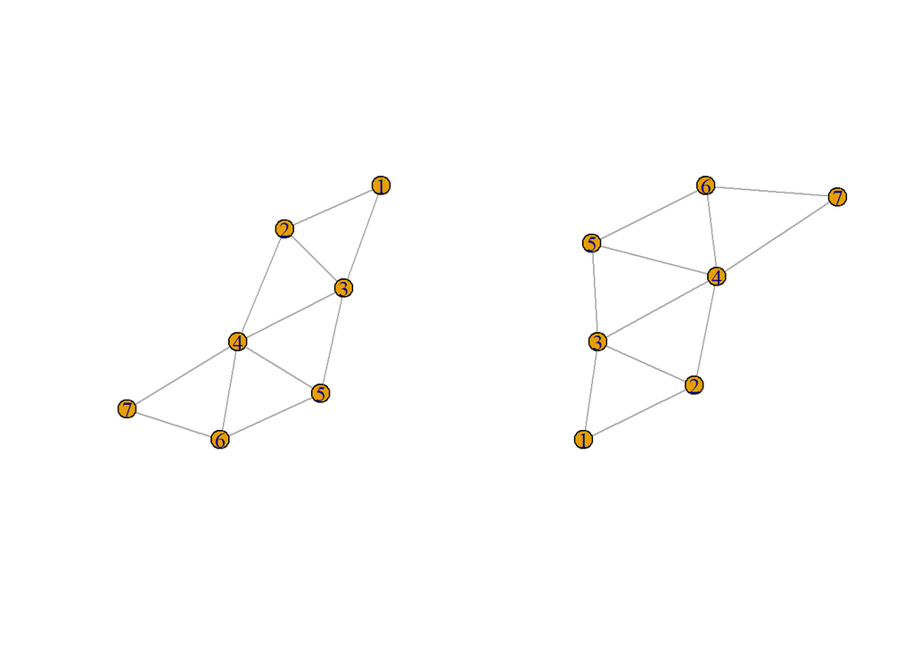

```r
EdgeList1 <- c(1,2, 1,3, 2,3, 3,5, 2,4, 4,5, 5,6, 4,6, 4,7, 6,7, 3,4)
EdgeList2 <- matrix(EdgeList1,nrow=2)
g1 <- graph(edges=EdgeList1, directed=FALSE)
g2 <- graph(edges=EdgeList2, directed=FALSE)
par(mfrow=c(1,2))
plot(g1)
plot(g2)
```

On obtient un objet de type `igraph` :

```r
class(g1)
```

```
## [1] "igraph"
```

On peut indiquer le nombre $n$ de noeuds du graphe quand certains noeuds sont isolés :

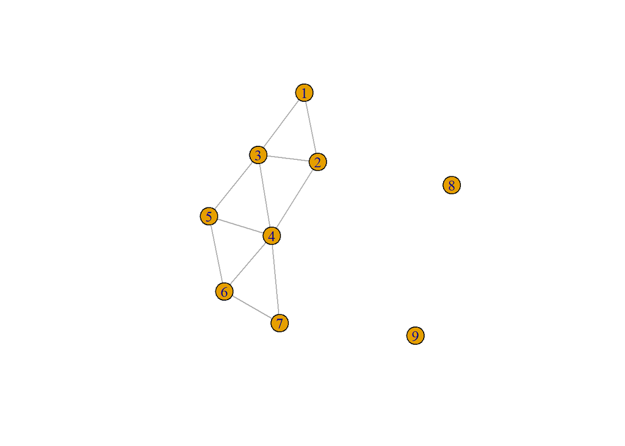

```r
g3 <- graph(edges=EdgeList1, n=9, directed=FALSE)
plot(g3)
```

Les noeuds ne sont pas nécessairement de type numerique :

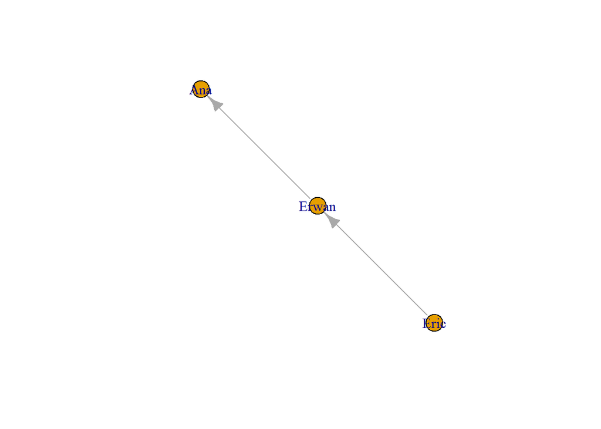

```r
EdgeListNames <- c("Eric", "Erwan", "Erwan","Ana")
g4 <- graph(edges=EdgeListNames)
plot(g4)
```

```r
# Notez que par défaut le graphe est dirigé
```

Avec des noeuds isolés :

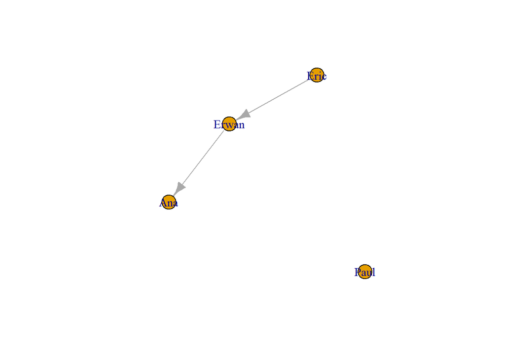

```r
g5 <- graph(edges=EdgeListNames, isolates="Paul")
plot(g5)
```

### 1.2. En important un `data.frame` contenant la liste d’arêtes :

Fichier de données disponible sur le site : http://www.sociopatterns.org/datasets/high-school-contact-and-friendship-networks/ et sur Moodle.

Données (au format csv) concernant des amitiés entre lycéens.

```r
friends <- read.table(file='Friendship-network_data_2013.csv')
head(friends)
```

|  | V1 | V2 |
| --- | --- | --- |
| 1 | 1 | 55 |
| 2 | 1 | 205 |
| 3 | 1 | 272 |
| 4 | 1 | 494 |
| 5 | 1 | 779 |
| 6 | 1 | 894 |

```r
amis <- graph_from_data_frame(friends, directed=TRUE)
amis
```

```
## IGRAPH 91402d8 DN-- 134 668 --
## + attr: name (v/c)
## + edges from 91402d8 (vertex names):
##  [1] 1 ->55  1 ->205 1 ->272 1 ->494 1 ->779 1 ->894 3 ->1   3 ->28  3 ->147
## [10] 3 ->272 3 ->407 3 ->674 3 ->884 27->63  27->173 28->202 28->327 28->353
## [19] 28->407 28->429 28->441 28->492 28->545 32->440 32->624 32->797 32->920
## [28] 34->151 34->277 34->502 34->866 45->48  45->79  45->335 45->496 45->601
## [37] 45->674 45->765 46->117 46->196 46->257 46->268 48->45  48->79  48->496
## [46] 55->1   55->170 55->205 55->252 55->272 55->779 55->883 55->894 61->797
## [55] 63->27  63->125 63->173 70->101 70->132 70->240 70->425 70->447 72->407
## [64] 72->674 72->857 79->45  79->48  79->335 79->496 79->601 79->674 79->765
## + ... omitted several edges
```

```r
class(amis)
```

```
## [1] "igraph"
```

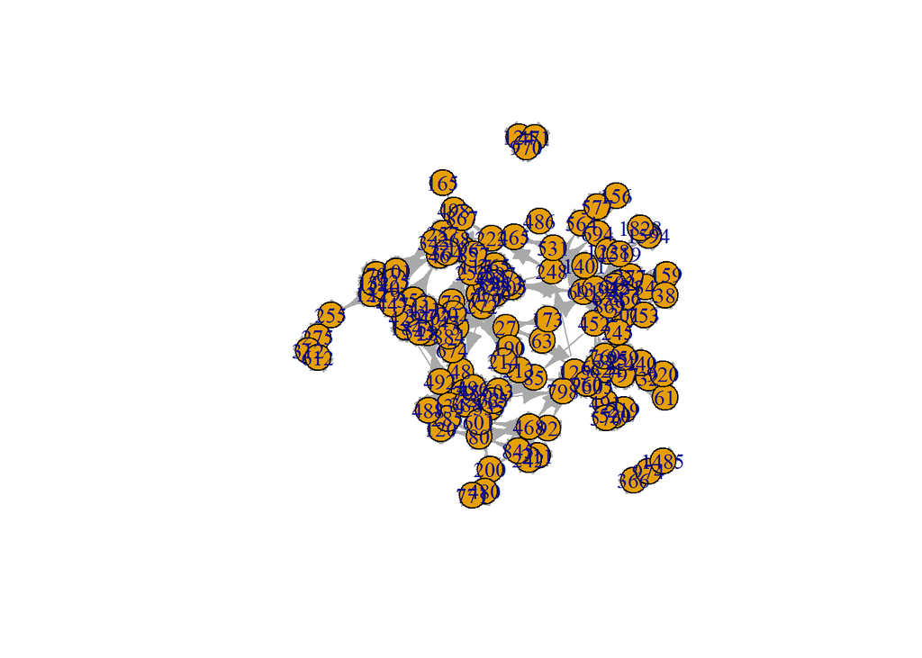

```r
plot(amis)
```

ou en important plusieurs `data.frame` (fichiers disponibles sur Moodle) :

Données concernant les medias ; 2 fichiers distincts, l’un contient la liste des medias avec des caractéristiques et l’autre contient les interactions (valuées et de plusieurs types) :

```r
nodes <- read.csv("Dataset1-Media-Example-NODES.csv", header=TRUE, as.is=TRUE)
head(nodes)
```

|  | id | media | media.type | type.label | audience.size |
| --- | --- | --- | --- | --- | --- |
| 1 | s01 | NY Times | 1 | Newspaper | 20 |
| 2 | s02 | Washington Post | 1 | Newspaper | 25 |
| 3 | s03 | Wall Street Journal | 1 | Newspaper | 30 |
| 4 | s04 | USA Today | 1 | Newspaper | 32 |
| 5 | s05 | LA Times | 1 | Newspaper | 20 |
| 6 | s06 | New York Post | 1 | Newspaper | 50 |

```r
links <- read.csv("Dataset1-Media-Example-EDGES.csv", header=TRUE, as.is=TRUE)
head(links)
```

|  | from | to | weight | type |
| --- | --- | --- | --- | --- |
| 1 | s01 | s02 | 10 | hyperlink |
| 2 | s01 | s02 | 12 | hyperlink |
| 3 | s01 | s03 | 22 | hyperlink |
| 4 | s01 | s04 | 21 | hyperlink |
| 5 | s04 | s11 | 22 | mention |
| 6 | s05 | s15 | 21 | mention |

```r
net <- graph_from_data_frame(d=links, vertices=nodes, directed=TRUE)
class(net)
```

```
## [1] "igraph"
```

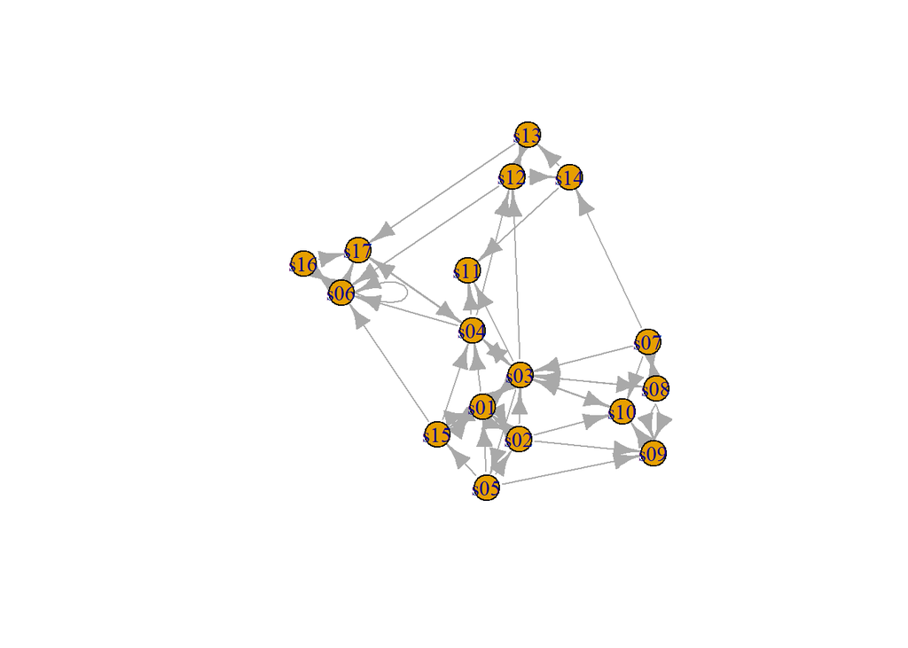

```r
plot(net)
```

### 1.3. À partir d’un fichier dont le format est adapté à `igraph` :

La fonction `read_graph` adaptée à certains formats de graphe :

```r
read_graph(file, format = c("edgelist", "pajek", "ncol", "lgl", "graphml", "dimacs", "graphdb", "gml", "dl"),...)
```

Graphe des personnages de l’oeuvre Les Misérables : lien si co-occurrence dans un chapitre. The file lesmis.gml contains the weighted network of co-appearances of characters in Victor Hugo’s novel *Les Miserables*. Nodes represent characters as indicated by the labels and edges connect any pair of characters that appear in the same chapter of the book. The values on the edges are the number of such co-appearances. http://www-personal.umich.edu/~mejn/netdata/

```r
miserab <- read_graph(file='lesmis.gml', format="gml")
class(miserab)
```

```
## [1] "igraph"
```

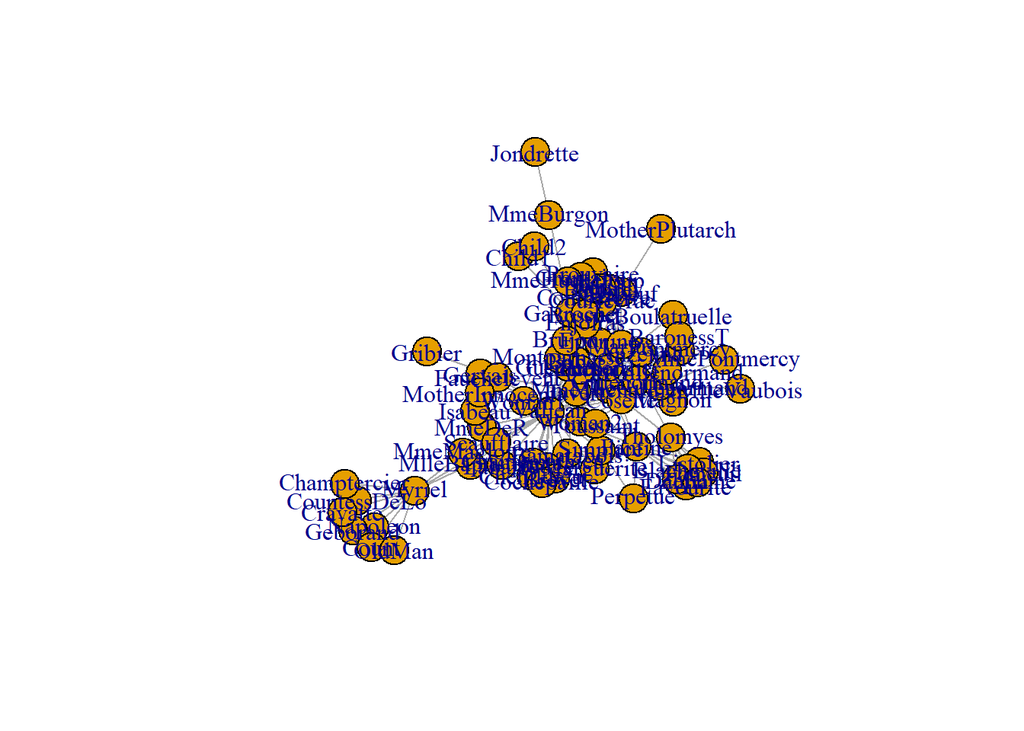

```r
plot(miserab)
```

### 1.4. À partir d’une matrice d’adjacence

```r
A <- matrix(c(0,0,0,0,0,0,1,1,0,1,0,1,0,1,1,0), 4, 4)
A
```

```
##      [,1] [,2] [,3] [,4]
## [1,]    0    0    0    0
## [2,]    0    0    1    1
## [3,]    0    1    0    1
## [4,]    0    1    1    0
```

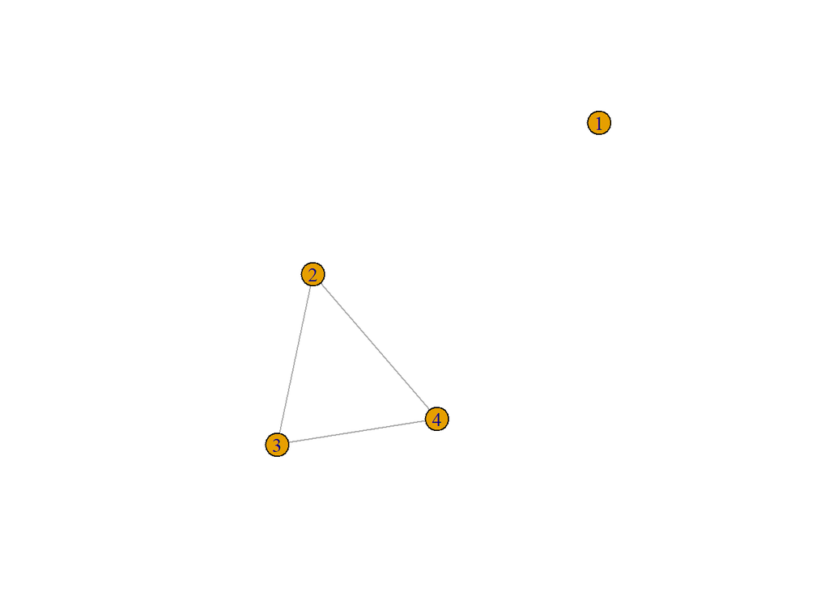

```r
plot(graph_from_adjacency_matrix(A, mode='undirected'))
```

## 2. Matrice d’adjacence

On peut convertir un graphe en matrice d’adjacence :

```r
Aamis <- as_adj(amis)
dim(Aamis)
```

```
## [1] 134 134
```

Attention, par défaut, `as_adj` crée une matrice au format *sparse* et certaines opérations classiques ne sont pas possibles :

```r
is.matrix(Aamis)
```

```
## [1] FALSE
```

```r
class(Aamis)
```

```
## [1] "dgCMatrix"
## attr(,"package")
## [1] "Matrix"
```

```r
t(Aamis)
```

```
## Error in t.default(Aamis): l'argument n'est pas une matrice
```

Pour y remédier, il suffit d’utliser l’option `sparse=FALSE` :

```r
Aamis <- as_adj(amis, sparse=FALSE)
is.matrix(Aamis)
```

```
## [1] TRUE
```

## 3. Propriétés simples d’un graphe

Familiarisez vous avec les fonctions suivantes en les appliquant sur les graphes crées ci-dessus. Prenez l’habitude d’utiliser la documentation du package (`help()`) et de la **LIRE** !

```r
vcount()
ecount()
V()
E()
is.directed()
```

## 4. Visualisation de graphes

### 4.1 Network layouts : algorithmes usuels de visualisation

Pour en savoir plus sur les différentes visualisations : https://igraph.org/r/doc/layout_.html

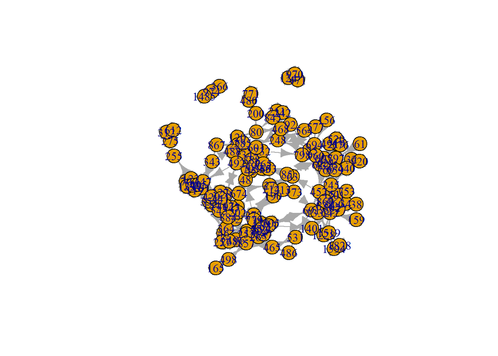

```r
plot(amis)
```

Pour choisir un layout spécifique, on utilise l’option suivante (utilisez la complétion automatique pour voir les layout possibles) :

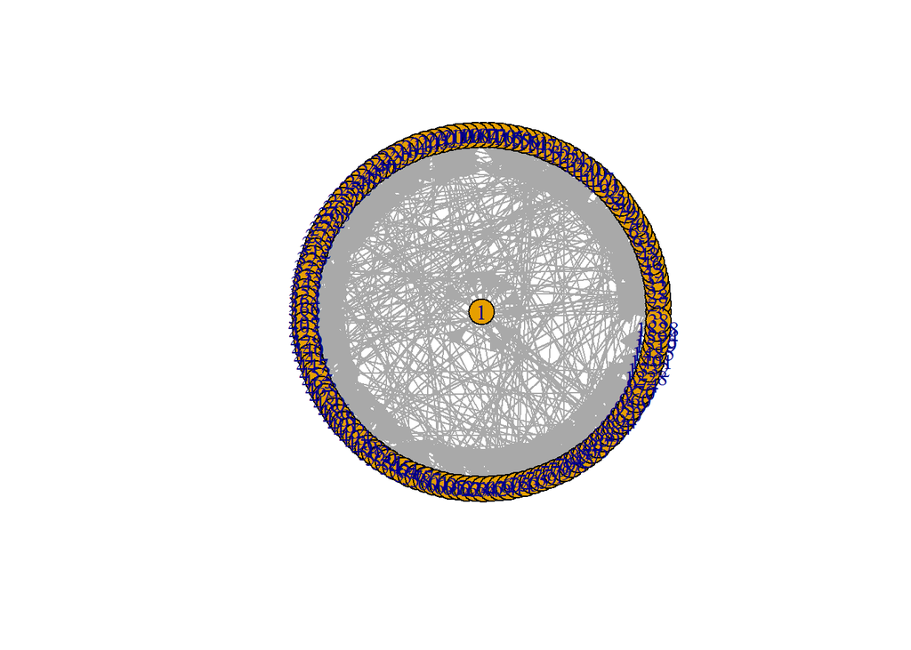

```r
plot(amis, layout=layout_as_star)
```

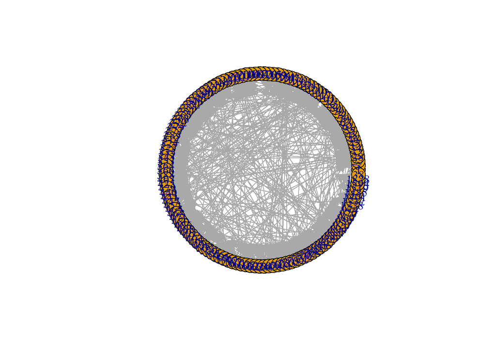

```r
plot(amis, layout=layout_in_circle)
```

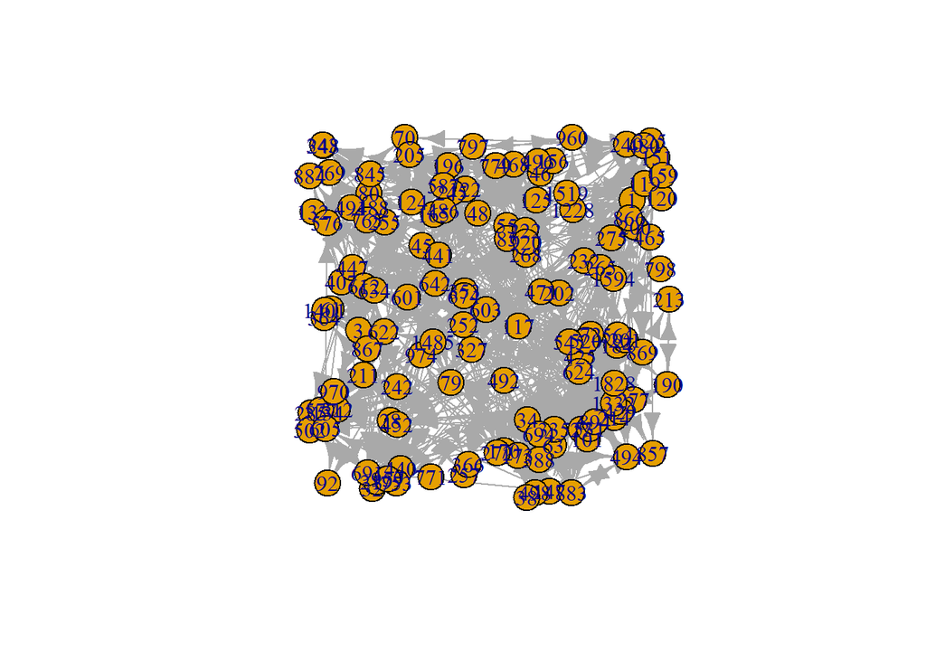

```r
plot(amis, layout=layout_randomly)
```

Deux algorithmes de visualisation populaires pour avoir des visulatisations jugées “esthétiques”. Si vous souhaitez plus d’infos : https://halshs.archives-ouvertes.fr/halshs-00839905/document

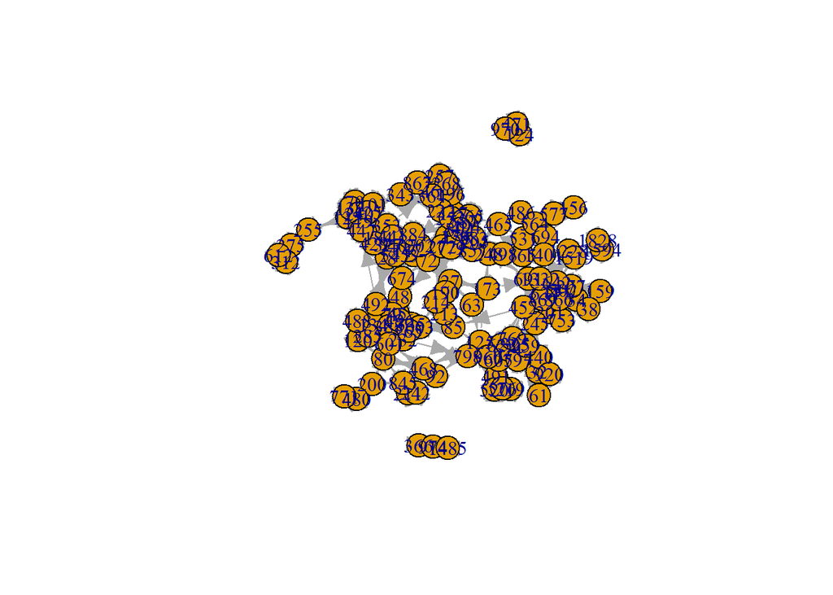

```r
plot(amis, layout=layout.fruchterman.reingold)
```

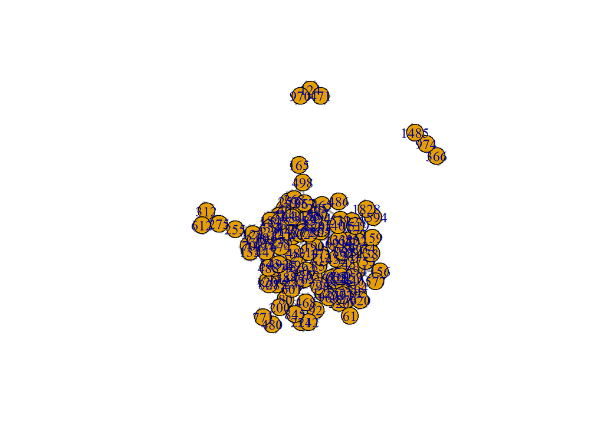

```r
plot(amis, layout=layout.kamada.kawai)
```

### 4.2 Embellir ses figures avec `igraph`

Pour voir toutes les option de `plot()` tapez `?igraph.plotting`.

Les options les plus courantes sont les suivantes :

- `vertex.color`, `vertex.shape`, `vertex.size`, `vertex.label` couleur, forme, taille et étiquettes des noeuds
- `edge.color`, `edge.label` couleur et étiquettes des arêtes

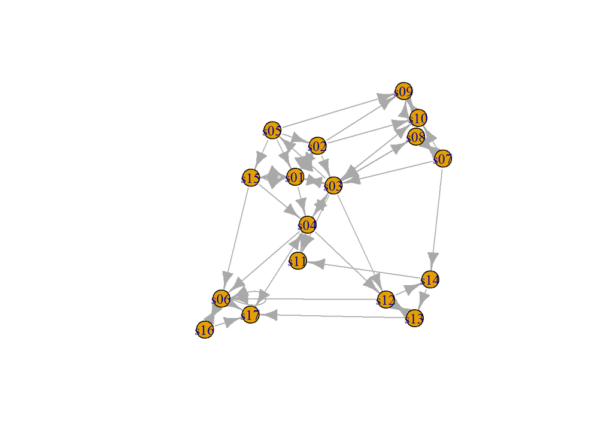

```r
plot(net)
```

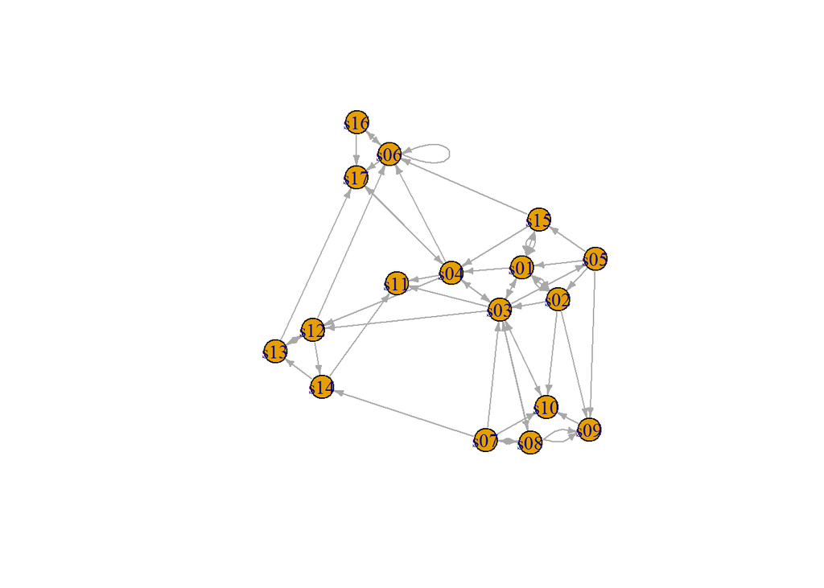

```r
plot(net, edge.arrow.size=.4)
```

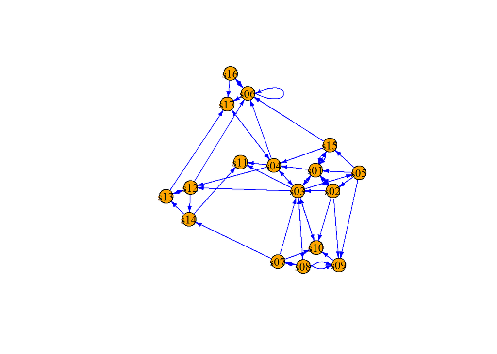

```r
plot(net, vertex.color="orange", edge.color="blue", vertex.label.color="black", edge.arrow.size=.4)
```

Si on veut utiliser des infos supplémentaires pour colorier les noeuds en fonction des covariables (ici le type de média, la taille des noeuds en fonction de l’audience, l’épaisseur des arêtes en fonction de leur poids…) ou sur les arêtes (ici valuées et de différents types) On trouve ces infos ici :

```r
vertex_attr(net)
```

```
## $name
##  [1] "s01" "s02" "s03" "s04" "s05" "s06" "s07" "s08" "s09" "s10" "s11" "s12"
## [13] "s13" "s14" "s15" "s16" "s17"
##
## $media
##  [1] "NY Times"            "Washington Post"     "Wall Street Journal"
##  [4] "USA Today"           "LA Times"            "New York Post"
##  [7] "CNN"                 "MSNBC"               "FOX News"
## [10] "ABC"                 "BBC"                 "Yahoo News"
## [13] "Google News"         "Reuters.com"         "NYTimes.com"
## [16] "WashingtonPost.com"  "AOL.com"
##
## $media.type
##  [1] 1 1 1 1 1 1 2 2 2 2 2 3 3 3 3 3 3
##
## $type.label
##  [1] "Newspaper" "Newspaper" "Newspaper" "Newspaper" "Newspaper" "Newspaper"
##  [7] "TV"        "TV"        "TV"        "TV"        "TV"        "Online"
## [13] "Online"    "Online"    "Online"    "Online"    "Online"
##
## $audience.size
##  [1] 20 25 30 32 20 50 56 34 60 23 34 33 23 12 24 28 33
```

```r
V(net)$media
```

```
##  [1] "NY Times"            "Washington Post"     "Wall Street Journal"
##  [4] "USA Today"           "LA Times"            "New York Post"
##  [7] "CNN"                 "MSNBC"               "FOX News"
## [10] "ABC"                 "BBC"                 "Yahoo News"
## [13] "Google News"         "Reuters.com"         "NYTimes.com"
## [16] "WashingtonPost.com"  "AOL.com"
```

```r
edge_attr(net)
```

```
## $weight
##  [1] 10 12 22 21 22 21 21 11 12 22 23 20 11 11 21 23 21 21 21 22 21 21 21 23 21
## [26] 22 22 21 21  2  5  1  1  2  2  3  1  1  1  1  2  2  4  2  4  4  4  1  1  1
## [51]  1  1
##
## $type
##  [1] "hyperlink" "hyperlink" "hyperlink" "hyperlink" "mention"   "mention"
##  [7] "mention"   "mention"   "mention"   "hyperlink" "hyperlink" "mention"
## [13] "hyperlink" "hyperlink" "mention"   "hyperlink" "hyperlink" "mention"
## [19] "mention"   "mention"   "hyperlink" "hyperlink" "hyperlink" "hyperlink"
## [25] "hyperlink" "hyperlink" "mention"   "mention"   "hyperlink" "hyperlink"
## [31] "hyperlink" "hyperlink" "mention"   "hyperlink" "mention"   "hyperlink"
## [37] "mention"   "hyperlink" "mention"   "hyperlink" "mention"   "mention"
## [43] "hyperlink" "hyperlink" "hyperlink" "mention"   "hyperlink" "hyperlink"
## [49] "mention"   "hyperlink" "hyperlink" "mention"
```

```r
E(net)$weight
```

```
##  [1] 10 12 22 21 22 21 21 11 12 22 23 20 11 11 21 23 21 21 21 22 21 21 21 23 21
## [26] 22 22 21 21  2  5  1  1  2  2  3  1  1  1  1  2  2  4  2  4  4  4  1  1  1
## [51]  1  1
```

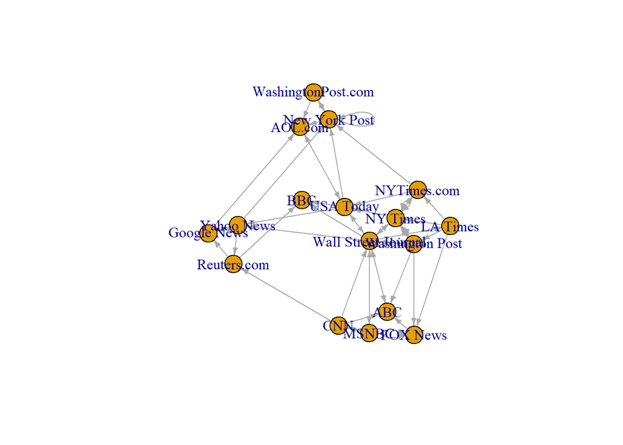

```r
plot(net, vertex.label=V(net)$media, edge.arrow.size=.4)
```

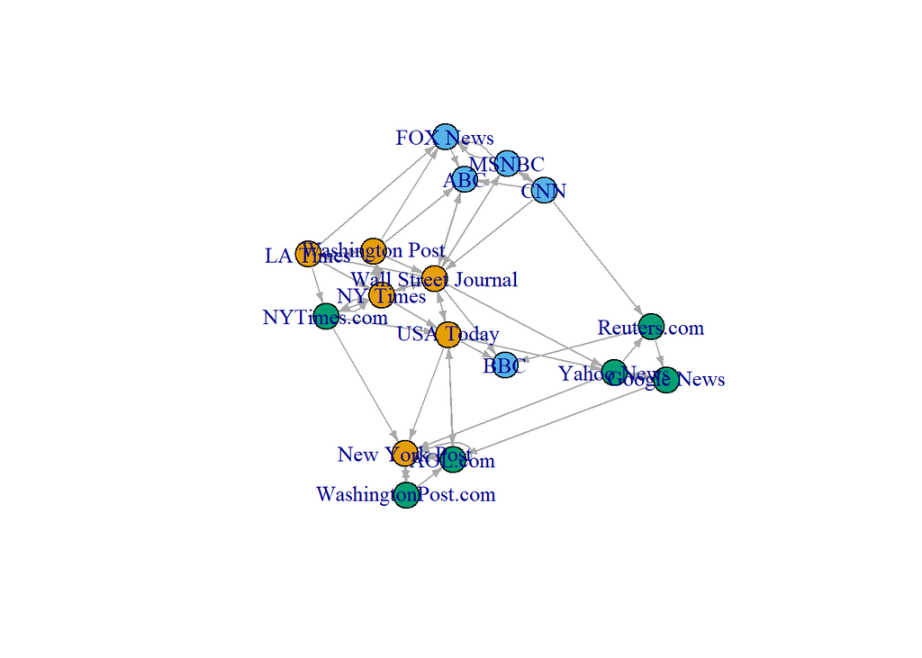

```r
plot(net, vertex.label=V(net)$media, edge.arrow.size=.4, vertex.color=V(net)$media.type)
```

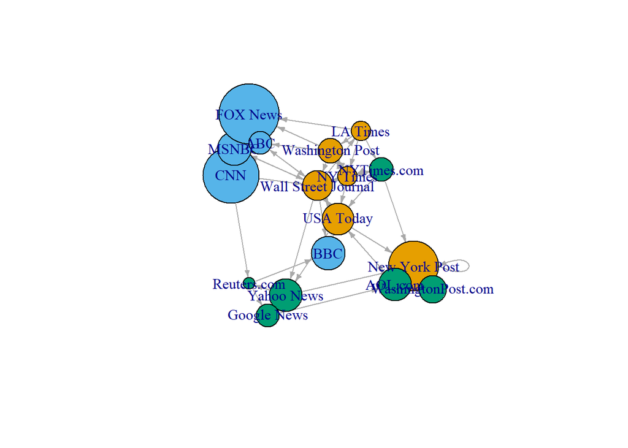

```r
plot(net, vertex.label=V(net)$media, edge.arrow.size=.4, vertex.color=V(net)$media.type, vertex.size=V(net)$audience.size)
```

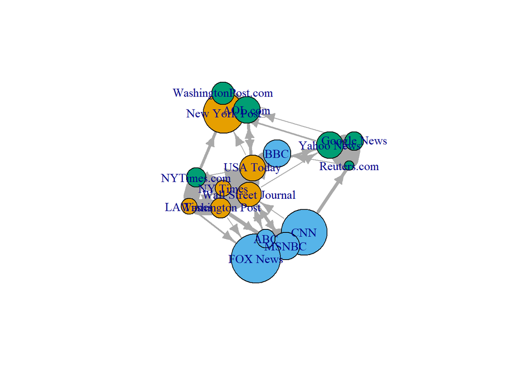

```r
plot(net, vertex.label=V(net)$media, vertex.color=V(net)$media.type, vertex.size=V(net)$audience.size, edge.width=E(net)$weight)
```

Pour changer la couleur du lien en fonction de son type

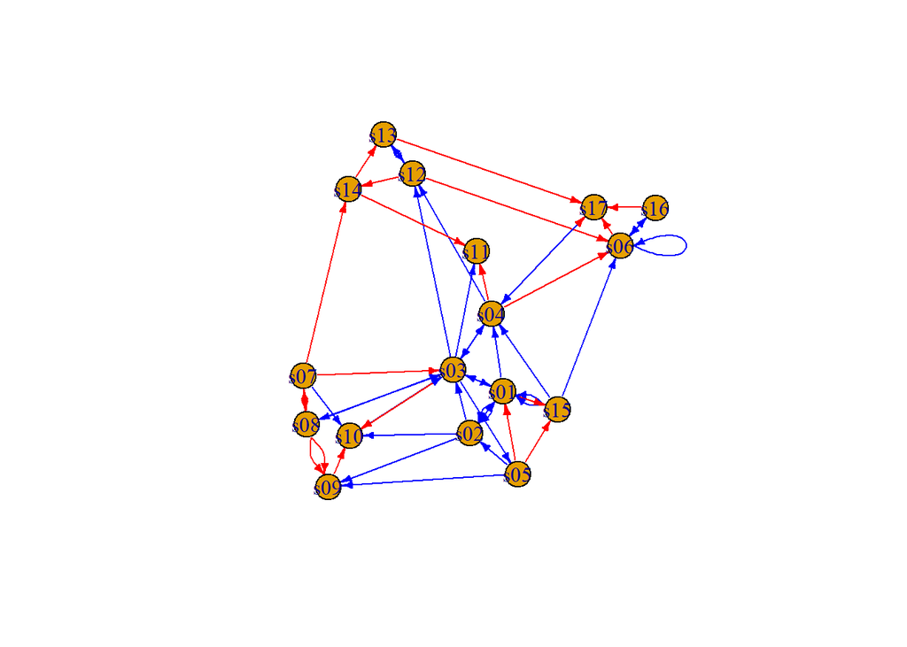

```r
E(net)$color[E(net)$type=="hyperlink"]<-"blue"
E(net)$color[E(net)$type=="mention"]<-"red"
plot(net, edge.arrow.size=.4)
```

# Exercice 1

Cherchez sur le web des graphes et importez-les sur votre machine (vous garderez l’adresse de récupération des données en commentaire dans votre fichier). Variez les formats d’origine si vous pouvez, et le type de graphe (dirigé ou non). Déterminez l’ordre et la taille des graphes et visualisez-les.

Voici une liste de serveurs proposant des données réelles de graphes :

- SocioPatterns research project http://www.sociopatterns.org/datasets/
- UC Irvine Network data repository http://networkdata.ics.uci.edu
- Page de Mark Newman http://www-personal.umich.edu/~mejn/netdata/
- Stanford Network Analysis Project (collection of large networks) https://snap.stanford.edu/data/index.html